# HW5

Brandon Owens

2024-03-27

```r
library(coda)
```

```r
library(ggplot2)
```

# Part II

## Part IIa.

```r
p1 <- c(11, 17, 16, 14, 15)
p2 <- c(12, 10, 15, 19, 11)
p3 <- c(23, 20, 18, 17)
p4 <- c(27, 33, 22, 26, 28)

sigma <- 3.25

p1_sample_mean <- mean(p1)
p2_sample_mean <- mean(p2)
p3_sample_mean <- mean(p3)
p4_sample_mean <- mean(p4)

p1_std_error <- sigma / sqrt(length(p1))
p2_std_error <- sigma / sqrt(length(p2))
p3_std_error <- sigma / sqrt(length(p3))
p4_std_error <- sigma / sqrt(length(p4))

package_means <- c(p1_sample_mean, p2_sample_mean, p3_sample_mean, p4_sample_mean)
package_std_errors <- c(p1_std_error, p2_std_error, p3_std_error, p4_std_error)

P = 4
```

```r
theta_update <- function(){
  theta_hat <- (((1/package_std_errors^2)*package_means) + (1/tau^2)*mu)/((1/package_std_errors^2) + (1/tau^2))
  V_theta <- (1/((1/package_std_errors^2) + (1/tau^2)))
  rnorm(P, theta_hat, sqrt(V_theta))
}

mu_update <- function(){
rnorm(1, mean(theta), tau/sqrt(P))
}

tau_update <- function(){
sqrt(sum((theta-mu)^2)/rchisq(1,P-1))
}
```

```r
iter <- 5000
sims <- array(NA, c(iter, P+2))

# Starting vals
mu <- rnorm(1, mean(c(p1,p2,p3,p4)), sigma)
tau <- runif(1, 0, sigma)

for (i in 1:iter){
  theta <- theta_update()
  mu <- mu_update()
  tau <- tau_update()
  sims[i,] <- c(theta, mu, tau)
}
```

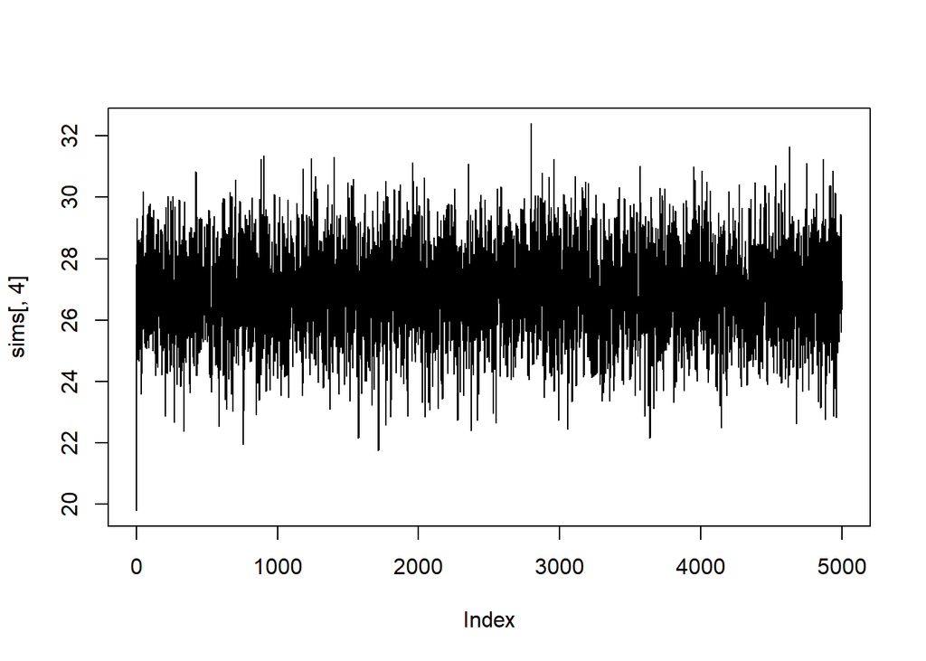

```r
p4 <- sims[, c(4, 6)]

plot(sims[,4],type="l")
```

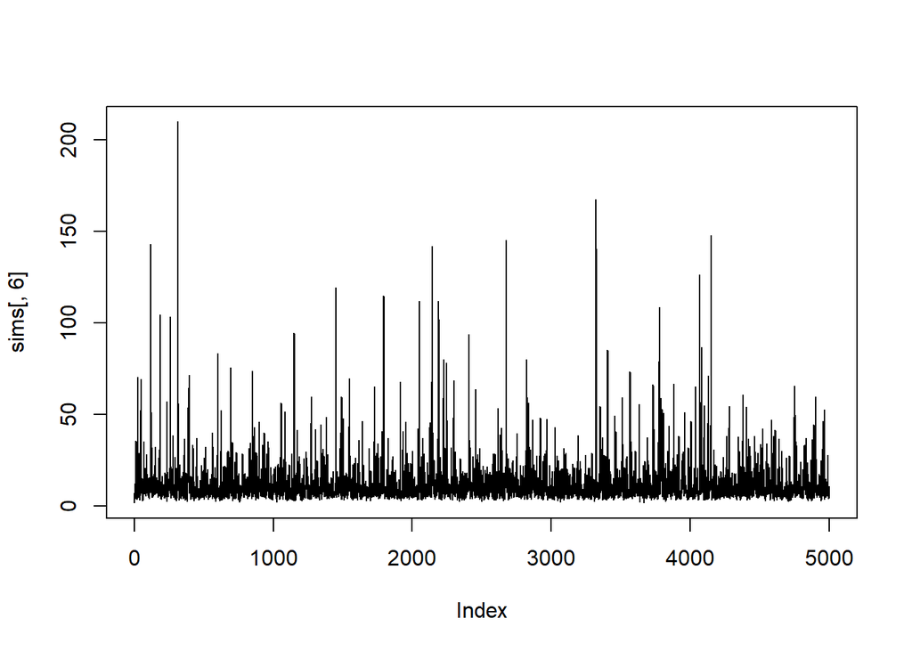

```r
plot(sims[,6],type="l")
```

```r
raftery.diag(p4[,c(1,2)], q=0.975)
```

```
##
## Quantile (q) = 0.975
## Accuracy (r) = +/- 0.005
## Probability (s) = 0.95
##
##  Burn-in  Total Lower bound  Dependence
##  (M)      (N)   (Nmin)       factor (I)
##  2        3741  3746         0.999
##  8        8732  3746         2.330
```

> **ANSWER:**  
> Total Chain Length: ~8500  
> Burn-In Length: 8  
> Thinning: Very low dependence factor, thinning may not be necessary. If we are to thin, we will include every other value after the burn in according to the Raferty diagnostic.

## Part IIb.

```r
iter <- 8500
burn <- 8 + 1
sims2 <- array(NA, c(iter, P+2))


# Starting values
mu <- rnorm(1, mean(c(p1,p2,p3,p4)), sigma)
tau <- runif(1, 0, sigma)

for (i in 1:iter){
  theta <- theta_update()
  mu <- mu_update()
  tau <- tau_update()
  sims2[i,] <- c(theta, mu, tau)
}

x <- sims2[burn:iter, ]
k=3

x <- x[k*(1:round((iter-burn)/k)), ]
```

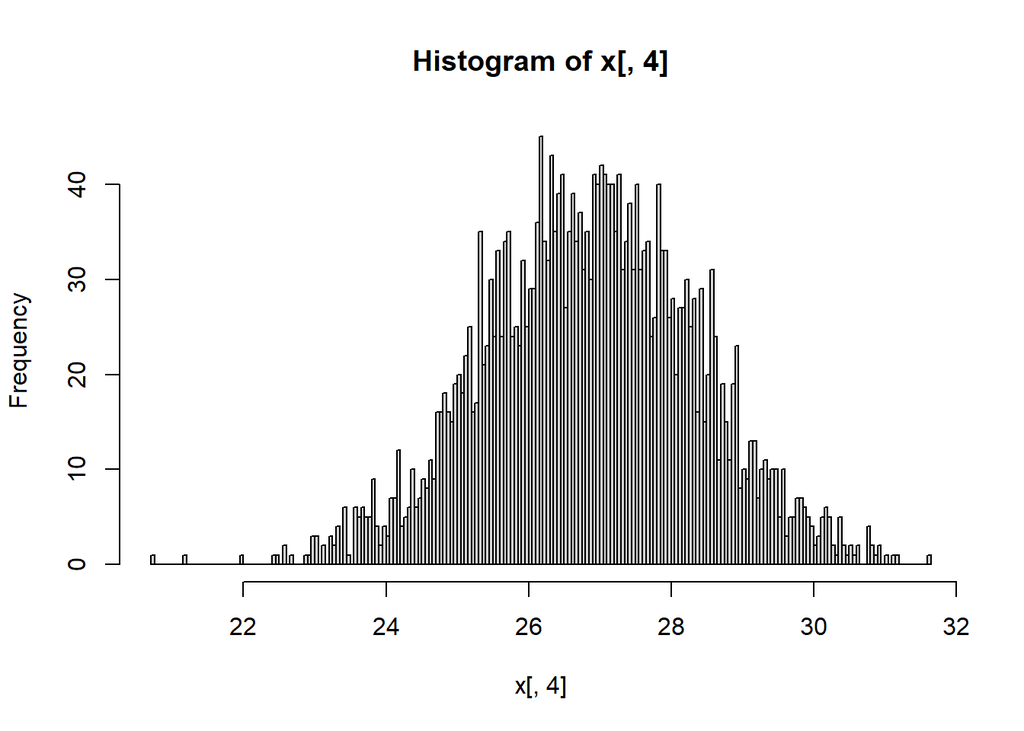

```r
hist(x[,4], breaks=200)
```

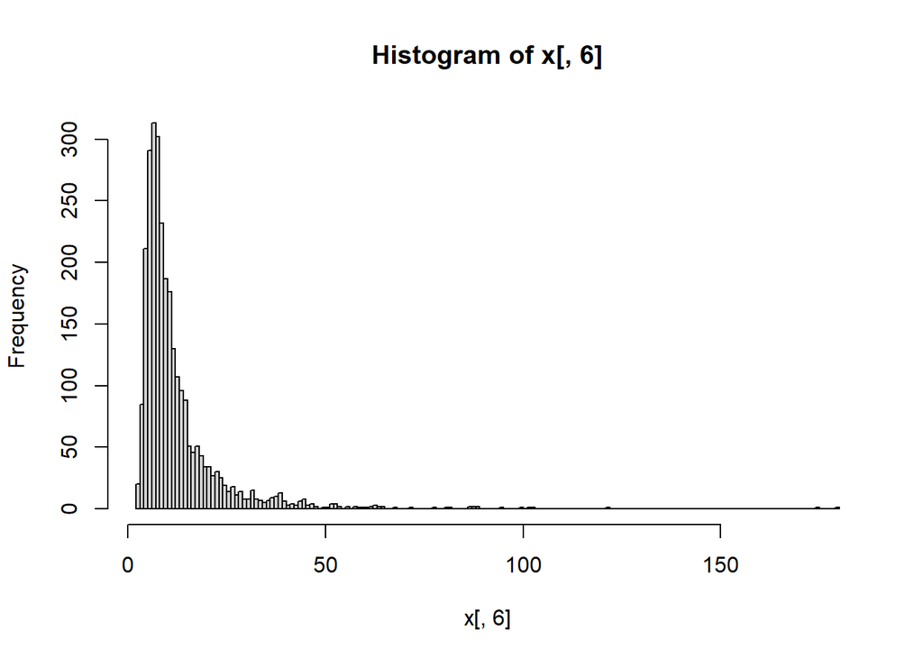

```r
hist(x[,6], breaks=200)
```

> **ANSWER:**  
> The last homework which focused on an analytical approach here had an extremely similar mean to this MCMC approach. Additionally, the tails of the distribution also appear to vary the same amount (converge near 22 and 32). As for hyperparameter tau, the MCMC also simulated the skewed nature of the distribution, but perhaps captured some larger outliers (also possible from the extended number of sims). With that being said, tau is similar (perhaps just slightly larger), but still has an MLE around the same area (7-12).

## Part IIc.

```r
p4m <- as.mcmc(x[,4])
taum <- as.mcmc(x[,6])

Mc = mcmc.list(p4m, taum)
heidel.diag(Mc)
```

```
## [[1]]
##
##      Stationarity start     p-value
##      test         iteration
## var1 passed       1         0.414
##
##      Halfwidth Mean Halfwidth
##      test
## var1 passed    26.9 0.0547
##
## [[2]]
##
##      Stationarity start     p-value
##      test         iteration
## var1 passed       1         0.648
##
##      Halfwidth Mean Halfwidth
##      test
## var1 passed    12.3 0.462
```